# Exercise for Lecture 5 - Differential expression with the limma package

The purpose of this exercise is to simulate some “microarray” data and explore how well different statistical tests separate truly differential expression (in a small sample situation). This will introduce you to: i) simulation; ii) metrics to assess statistical performance; iii) some variations of the t-test.

Specifically, we will create a synthetic dataset with replicates from 2 experimental conditions and put in differential expression for some features. The goal is to see how well different statistical summaries can distinguish between those “truly” differential and those not differential.

Below is some R code to get you started.

Previous path file: > .libPaths() [1] “C:/ProgramData/App-V/3B93D255-7D91-49DC-B5B0-49E0FACC68F4/58E809DE-7D4D-4F74-BA81-34C5267AAD64/Root/VFS/ProgramFilesX64/R_x64_3.x/library”

```r
.libPaths("C:/Users/statzerc/Desktop/%HOMESHARE%/R3UserLibs") #set the library
library("limma")
#source("https://bioconductor.org/biocLite.R")
#biocLite("limma")
```

#### Simulation of Microarray datasets:

Here we simulated a microarray experiment: a control in triplicate and an experimental condition in triplicate. In our simlation we set the first 1’000 gene set probes to be differentially expressed by adding a ‘true LogFC’ of 2 to the simulated normally distributed data.

```r
nGenes <- 10000                   # number of "features"
nSamples <- 6                     # number of samples (split equal in 2 groups)
pDiff <- .1                       # percent of genes "differential
grp <- rep(0:1,each=nSamples/2)   # dummy variable for exp. group
trueFC <- 2                       # log-fold-change of truly DE

d0 <- 1
s0 <- 0.8
sd <- s0*sqrt(d0/rchisq(nGenes,df=d0))  # dist'n of s.d.
```

Note: there are some details regarding the scaled inverse chi-square distribution that you may want to explore. For example, see the [wiki description](http://en.wikipedia.org/wiki/Scaled_inverse_chi-square_distribution).

#### Question 1. Look at the distribution of “true” s.d. (each gene has a different s.d.). You will change this distribution later to see effect on differential detection performance.

Next, we can generate a table of (null) data:

```r
y <- matrix(rnorm(nGenes*nSamples,sd=sd),
            nr=nGenes,nc=nSamples)
```

And, we can add in “differential expression”, randomly chosen to be in the positive or negative direction, to a set of indices chosen:

```r
indD <- 1:floor(pDiff*nGenes)
diff <- sample(c(-1,1),max(indD),replace=TRUE)*trueFC
y[indD,grp==1] <- y[indD,grp==1] + diff
```

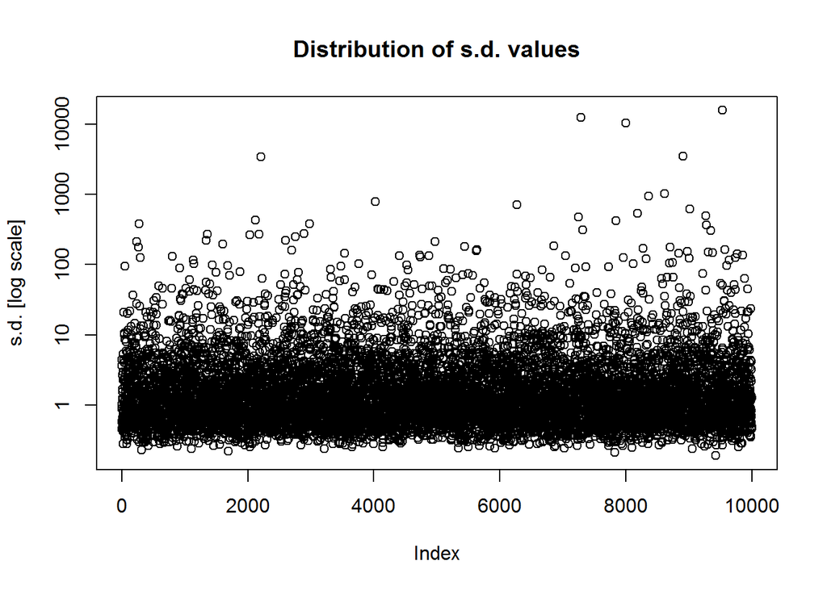

```r
plot(sd, log="y",main="Distribution of s.d. values",ylab="s.d. [log scale]")
```

#### Question 2. To make sure you understand the simulation, look at some of the rows in the table. For example, plot the data (e.g., a barplot) for a few rows that are truly differential and a few rows that are non-differential.

##### Rows of the simulated table

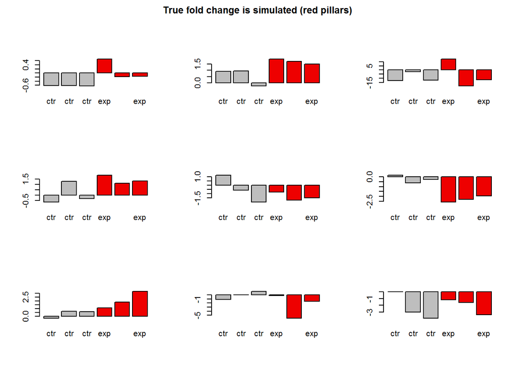

```r
#True fold change:
TrueRows = sample(1:1000,9,replace = FALSE)
colnames(y) <- rep(c("ctr","exp"), each = nSamples/2 )
par(mfrow=c(3,3),oma=c(0,0,2,0))
for(rows in TrueRows){
  barplot(y[rows,],names.arg = colnames(y),col = rep(c("grey","red2"),each=3))
}
title("True fold change is simulated (red pillars)",outer = TRUE)
```

9 rows of the simulated data are randomly picked out of the first 1000 rows - the part of the table which corresponds to the true logFC data.

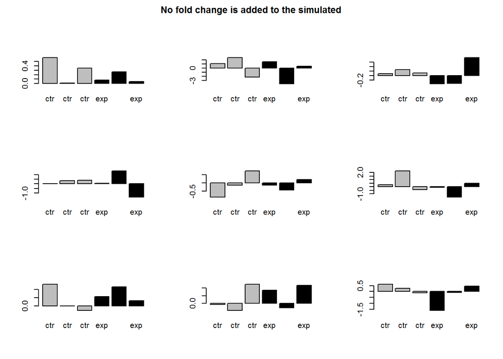

```r
#No fold change added to random values:
FalseRows = sample(1001:nrow(y),9,replace = FALSE)
colnames(y) <- rep(c("ctr","exp"), each = nSamples/2 )
par(mfrow=c(3,3),oma=c(0,0,2,0))
for(rows in FalseRows){
  barplot(y[rows,],names.arg = colnames(y),col = rep(c("grey","black"),each=3))
}
title("No fold change is added to the simulated",outer = TRUE)
```

9 rows of the simulated data are randomly picked out of the last 9000 rows - the part of the table which does not contain a “true” logFC difference.

##### Design matrix

Next, we create a design matrix to feed into limma:

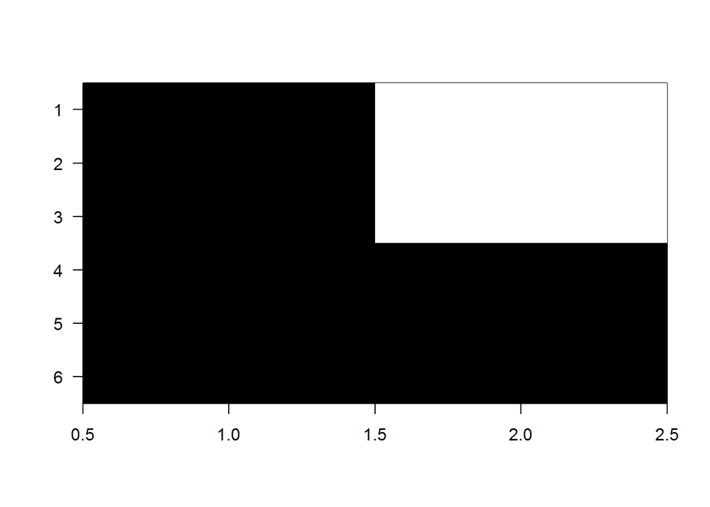

```r
#install.packages("rafalib")
library(rafalib)
design <- model.matrix(~grp)
imagemat(design)
```

#### Question 3. What is the interpretation of the two columns of this design matrix?

Below is a standard limma pipeline. We will unravel many details of these steps in the coming weeks.

```r
fit <- lmFit(y,design)
fit <- eBayes(fit)
```

#### Question 4. For each row in the simulated table, calculate the classical 2-sample t-test (perhaps store the result in a vector named ‘classicalt’; see below). See ?t.test for more details about the built-in R function to do this calculation and convince yourself which arguments to use to match the t-test described in class.

```r
classicalt <- apply(y[,],1,function(mat) {t.test(x = mat[1:3], y = mat[4:6])$statistic}) #Use $p.value to only get p-values
```

Below, a vector of colours is made to signify the true differential “status”, which will be used in exploratory plots:

```r
cols <- rep("black",nrow(y))
cols[indD] <- "blue"
```

#### Question 5. Add an exploratory visualization to your plots above, perhaps with a command similar to below. From this visualization, summarize any differences you see between the three statistical summaries of a change between experimental groups.

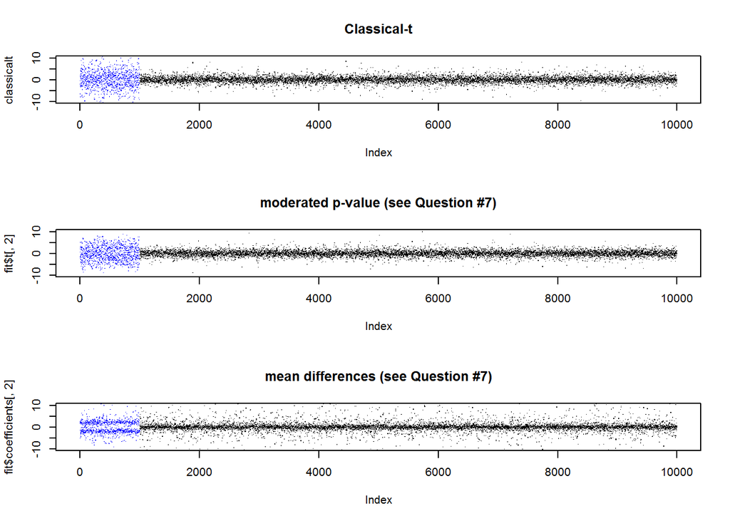

```r
#I got stuck trying to extract the moderated p-values and mean differences from the fit.
par(mfrow = c(3,1))
plot( classicalt, col=cols, ylim=c(-10,10), pch=".", main="Classical-t" )
plot( fit$t[,2], col=cols, ylim=c(-10,10), pch=".", main="moderated p-value (see Question #7)" )
plot( fit$coefficients[,2], col=cols, ylim=c(-10,10), pch=".", main="mean differences (see Question #7)")
```

Remark: the distribution of the mean differences appear to be bimodal while the moderated p-values and the classical-t are unimodal. Since we add logFC of +/-2 in the first 1000 samples in the dataset we expect the distribution of the means to be bimodal.

#### Question 6. Pick a reasonable metric to compare the methods: ROC curve, false discovery plot, power versus achieved FDR. Using this metric/curve, compare the classical t-test (classicalt), the moderated t-test (fit$t) and the log-fold-change or mean difference (fit$coef). Either manually calculate and plot it or use a nice package for it (e.g., https://rocr.bioinf.mpi-sb.mpg.de/ or https://github.com/markrobinsonuzh/benchmarkR) What method(s) perform well?

# Get from github

```r
# source("https://bioconductor.org/biocLite.R")
# biocLite("BiocStyle")
# install.packages("devtools")
library(devtools)
devtools::install_github("markrobinsonuzh/benchmarkR")
library(benchmarkR)
pvals_tstat <- apply(y[,],1,function(mat) {t.test(x = mat[1:3], y = mat[4:6])$p.value}) #Use $p.value to only get p-values
label = c(rep(1,1000),rep(0,9000))
re <- SimResults(pval = pvals_tstat, labels = label, padj = NULL, padjMethod = c("hommel"))
```

```
## padj is missing, selected method (hommel) is used to generate padj.
```

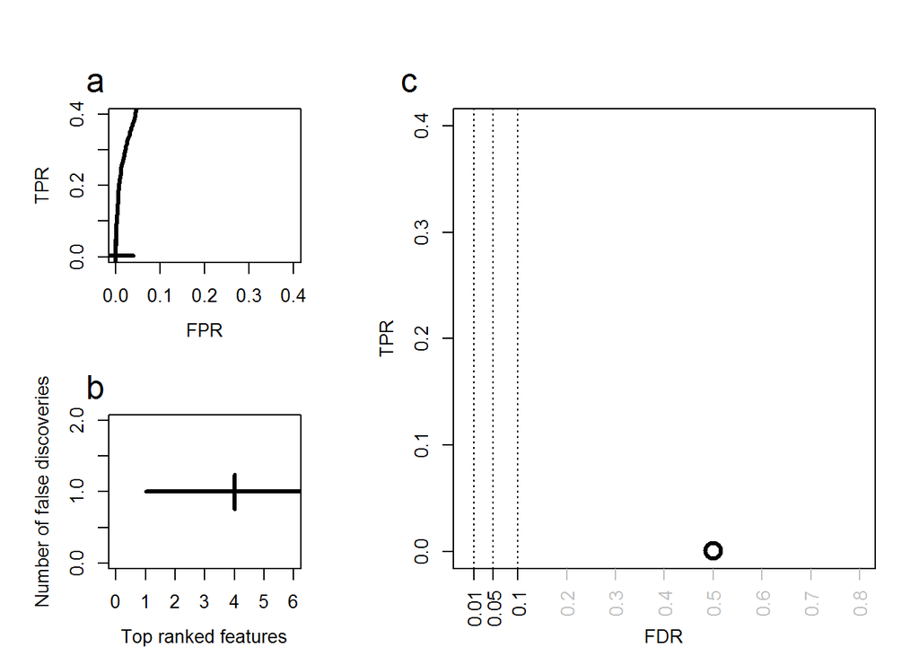

```r
benchmarkR(re)
```

```r
library(benchmarkR)
#Obtain the p.values of the different methods
tstat <- apply(y[,],1,function(mat) {t.test(x = mat[1:3], y = mat[4:6])$p.value})
pval_moderated <- fit$t[,2]
pval_log_FC <- fit$coefficients[,2]
methods = list(A=tstat, B=pval_moderated, C=pval_log_FC)

#Generate label
label = c(rep(1,1000),rep(0,9000))

meth = cbind(tstat = tstat, moderated = pval_moderated, pval_log_FC = pval_log_FC)
object = list(pval = meth, labels = label)
compare <- SimResults(pval = object$pval, labels = object$labels, padj = NULL)
```

```
## padj is missing, selected method (BH) is used to generate padj.
```

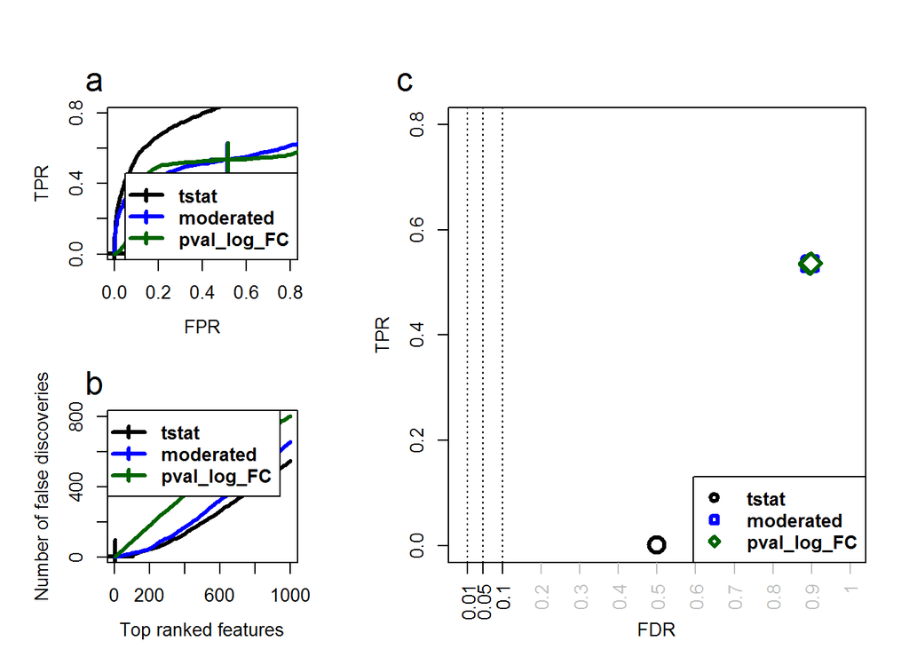

```r
benchmarkR(compare)
```

#### Question 7. Explore the performance of these test statistics for a few scenarios. For example, change the sample size, the number of genes DE, magnitude of the difference, level of variability. What influence do these parameters have on the relative performance?

I changed the specified parameters and ran the comparitive analysis. However I don’t think the data is relevant because I could not correctly extract the moderated p-values and the mean differences properly (see benchmarkR plot).

#### Note: Submit both an Rmarkdown/markdown file as well as a compiled HTML file to your private github repository.

Submitted